# ACCUEIL

[figure not shown]

Cochin - Port-Royal

**SERVICE de GYNECOLOGIE-OBSTETRIQUE II ET MÉDECINE de la REPRODUCTION**

Chef de service : **Professeur Charles Chapron**

[figure not shown]

# FONCTIONNEMENT DU SERVICE

### CHIRURGIE

| PU.PH | . |
| --- | --- |
|  | Pr Charles CHAPRON |
|  | Pr Bruno BORGHESE |
| PH |  |
|  | Dr Antoine BOURRET |
|  | Dr Laetitia CAMPIN |
|  | Dr Hervé FOULOT |
|  | Dr Paul MARZOUK |
|  | Dr Guillaume PIERRE |
| MCU-PH |  |
|  | Dr Louis MARCELLIN |
| CCA/Assistants |  |
|  | Dr Carole ABO |
|  | Dr Antoine GAUDET CHARDONNET |
|  | Dr Florie PIROT |
| P. Attachés |  |
|  | Dr Amine BITITI |
|  | Dr Fouzia DECUYPERE |

### MÉDECINE DE LA REPRODUCTION

| PU.PH | . |
| --- | --- |
|  | Pr Pietro SANTULLI |
| PH |  |
|  | Dr Chloé MAIGNIEN |
| CCA/Assistants |  |
|  | Dr Mathilde BOURDON |
|  | Dr Fleur KEFELIAN |
|  | Dr Sonia KOUNTCHINSKY |
|  | Dr Sarah BLAIS |
|  | Dr Asim ALWOHAIBI |
|  | Dr Marion OUAZANA |
| PHC |  |
|  | Dr Sarah ESKENAZI |
| P. Attachés |  |
|  | Dr Stéphane DOUARD |
|  | Dr Alessandra FUBINI |
|  | Dr Vanessa GAYET |
|  | Dr Anne MARSZALEK |

### INTERNES DU SERVICE

| . | Interne |
| --- | --- |
| Chirurgie gynecologique | Marly BAH |
|  | Sunita HANMER |
|  | Samia OUASTI |
|  | Celia MAHEUT |
| Medecine générale | Aurore BAUCHET |
|  | Tifanny MAZETIER |
|  | Flora PETROT |
| Medecine de la reproduction | Rami EL HACHEM |
|  | Timon JOBIN |
|  | Axel VEYRIE |

Anciennes promotions d’internes

### PRÉSENTATION DU SERVICE

#### Le bloc opératoire

L’activité chirurgicale couvre l’ensemble des techniques opératoires susceptibles d’être effectuées en chirurgie gynécologique (endoscopie opératoire : cœliochirurgie ; hystéroscopie opératoire ; chirurgie vaginale ; laparotomie) dans tous les domaines de la spécialité (cancérologie, douleurs abdomino-pelviennes, symptomatologie fonctionnelle hémorragique, prolapsus, infertilité)

Les internes sont présents **tous les jours au bloc opératoire**.

Leur participation à plein temps à l’activité opératoire est l’objectif prioritaire de ce stage.

Le programme froid est réparti sur trois salles :

- Salle 2 et 3 du lundi au vendredi : **8 h à 18 h**
- **Salle 1 Robot** le mercredi : **8 h à 18 h**
- UCA salle 4 du lundi au vendredi : **8 h à 17 h**

Chaque opérateur à un jour fixe (voir planning) et le programme froid est validé une semaine à l’avance au cours du staff opératoire assuré le mardi par le **Dr Paul MARZOUK**

#### L’hospitalisation

Le service comprend 28 lits d’hospitalisation traditionnelle,

Une **visite le matin** et une **contre-visite le soir** sont effectuées **tous les jours, week-end compris**.

Durant la semaine, **la visite commence le matin impérativement à 7h10 avec les externes et infirmières**, afin que toutes les consignes aient été données et tous les problèmes réglés pour **7h50 au plus tard**.

Toutes les patientes opérées en ambulatoire (HdJ) doivent avoir été vues avant leur intervention.

La contre-visite se fait en fin d’après-midi. Elle doit être terminée avant 19h.

**La contre-visite en Hôpital de jour doit être faite par l’interne de l’UCA.**

Le samedi matin la visite se fait impérativement à 8 h et doit être terminée avant le début de du staff de la garde du samedi à 9h00.

La visite du dimanche et les contre-visites du week-end sont effectuées par l’interne de garde de gynécologie (BIP2). Attention pour les week-ends de garde assuré par les internes de PMA, **les internes de chirurgie viennent faire la visite le matin (samedi et/ou dimanche)**.

Chaque jour sont désignés pour l’hospitalisation et la gestion des urgences :

- Un senior d’astreinte responsable.
- Un interne d’astreinte qui a le BIP de gynécologie (15 426).

Un planning de répartition (bloc / astreinte / absence / vacance) des internes et des séniors est demandé au minimum au début de chaque mois pour affichage en salle de staff de gynécologie.

#### Les staffs :

- **Le staff chirurgical** : tous les matins à 7h50 (précise) en salle de réunion du Rdj salle 3: cf. Fonctionnement des urgences.
- **Le staff opératoire** : tous les mardis à 17 heures à la chefferie de service.
- **Le staff de cancérologie** : tous les jeudis matins de 8 heures à 9 h (les blocs de chirurgie commencent à 9 heures).

**Présence obligatoire pour tous les internes** : RDJ salle 3.

À cette réunion participent, outre les membres du service (gynécologues, cadres, assistante sociale, psychologue…), les oncologues médicaux, les anatomopathologistes, les radiologues, les radiothérapeutes.

#### Enseignement et Recherche :

- Cours à tous les internes du service
  - Organisés en salle de réunion de la chefferie du 2e étage
  - **tous les mardis à 18 heures**.
  - Responsable : Dr Mathilde BOURDON.
- Organisation dans le service de deux diplômes universitaires :
- DU de Gynécologie de l’infertilité et AMP (Pr SANTULLI)
- DU de ménopause (Pr PLU BUREAU)
- De nombreux travaux scientifiques sont en cours ou en préparation.

Les internes intéressés, soit pour participer à une publication scientifique, soit pour faire leur thèse ou bien rédiger leur mémoire de DES, doivent se manifester en début de semestre.

### RÉPARTITION DES INTERNES

**Un planning** de la répartition des internes doit être effectué AU MINIMUN tous les mois, transmis au **Pr BORGHESE** pour affichage en salle de staff

#### Interne de BIP

Il garde le DECT (15426)

Gère les problèmes en journée des salles d’hospitalisation et des urgences **pour toute la semaine** du lundi 8 heures jusqu’au samedi 12 heures.

Pour les patientes enceintes le terme maximum des patientes gérées par le service de gynécologie aux urgences = 14+ 6 SA. Au-delà de 15 SA, c’est l’équipe d’obstétrique qui prend le relai.

Est disponible pour des avis ou voir les patientes se présentant aux consultations post-urgences

Travaille en étroite collaboration avec le senior responsable de l’astreinte pour régler les problèmes médico-chirurgicaux et la gestion des lits.

Au cours d’une même semaine, ce poste doit être assuré tous les jours **par le même interne**. Cette condition est indispensable au bon fonctionnement du service et à une meilleure gestion du suivi postopératoire.

#### Internes de bloc :

Les internes de bloc sont responsables de la rédaction des CRH des patientes qu’ils ont opérées sur le logiciel Orbis (accessible sur n’importe quel poste).

IVG : Les **mardis**, ainsi qu’**un vendredi par mois** les internes de gynécologies sont responsables des **IVG de 8H à 11H**. Les patientes doivent être codées sur CCAM avec l’Identifiant : CHAPR code : Charles, et le compte rendu opératoire doit être fait entrant la date des dernières règles.

### ACTIVITÉS DES INTERNES

#### ACTIVITÉS DE L’INTERNE RESPONSABLE DE LA SALLE

**Les internes sont affectés à une salle d’hospitalisation pour l’ensemble du semestre**.

**CCA responsables de salle :**

- Dr ABO / Dr GAUDET CHARDONNET salle René MUSSET
- Dr PIROT salle Raoul PALMER

#### La visite

La visite doit être effectuée par le même interne sur une semaine avec l’infirmière responsable de la salle et un externe.

Elle démarre à 7h10 précises. Le CCA de la salle est présent à partir de 7 h 30 pour voir les patientes hospitalisées pendant la garde et les patientes opérées nécessitant un avis séniorisé. Les dossiers de ces patientes pourront ainsi être discutés efficacement au staff quotidien à 7 h 50.

Le samedi matin la visite a lieu à 8 h, avant le début du staff commun de gynécologie et d’Obstétrique à 9 h au RJ.

Le dimanche matin elle est effectuée par l’interne de gynécologie qui est de garde.

Au cours de cette visite, les prescriptions journalières sont retranscrites sur le logiciel Actipidos et les examens complémentaires récupérés.

Les externes aident à récupérer les examens complémentaires à mettre à jour les questionnaires épidémiologiques et les dossiers médicaux.

Pour chaque patiente un mot d’évolution biquotidien (date et heure) (visite et CV) ainsi qu’un mot de sortie doit inscrits dans le dossier Orbis.

Les ordonnances et papiers de sortie sont également faits durant la visite, ils ont au mieux été préparés la veille durant la contre-visite.

Si besoin d’une échographie pelvienne (3 box d’échographie gynéco au 2e étage)

- Dr Joëlle UZAN-AUGUI, disponible pour les patientes hospitalisées,
- Vacation d’échographie référent pelvienne tous les après-midi à partir de 14h00

En cas de complication postopératoire (week-end compris), le chef de clinique d’astreinte et le médecin qui a opéré la patiente doivent impérativement être prévenus.

**Vous devez impérativement respecter les dates de sortie déjà fixées par le chirurgien et validées au cours du staff opératoire** et spécifiées dans le planning des lits.

**Toute décision de modification** de date de sortie ne peut être **prise que par l’opérateur** de la patiente. En cas de patiente hospitalisée en urgence, mais non opérée, la décision de sortie ne peut être prise qu’en accord avec le CCA responsable de salle ou avec le sénior d’astreinte.

#### La contre-visite

Elle doit être faite tous les jours de la semaine en fin d’après-midi **avant 19 heures** par l’interne responsable de la salle. Attention **la garde commence à 18 heures**.

Durant le week-end elle est effectuée par l’interne de gynécologie qui se libère entre 18h et 19 h pour faire la contre-visite.

La contre-visite permet de voir les patientes déjà opérées ainsi que les patientes qui seront opérées le lendemain.

**Les prescriptions préopératoires** (misprostol, Normacol, hCG urinaires…) doivent être effectuées avec un mot d’entrée dans le dossier : la **date des dernières règles** et un **traitement hormonal en cours** doivent systématiquement être précisés.

Lors de la contre-visite, l’interne doit, pour chaque femme ≤ 42 ans ayant subi une cœlioscopie ou une laparotomie, vérifier la **fiche épidémiologique** et s’assurer qu’elle est correctement remplie par le chirurgien.

Cette contre-visite permet également de faire les éventuelles sorties (curetage, hystéroscopie…) et de préparer celles du lendemain.

En cas de problème, il faut en informer le chef d’astreinte, week-end compris.

En pratique, la veille de l’intervention, il faut vérifier et/ou prescrire :

- **hCG urinaires** : DDR à mentionner impérativement dans le dossier
- **Traitement médical habituel** : Préciser impérativement le type de traitement hormonal
- **ECBU** avant chaque cure de prolapsus ou une montée de JJ ou de cure d’IUE type TOT
- **Atarax 25 mg** si besoin
- **Paracétamol** : 1g*4 / jour si douleur

**À vérifier et à retranscrire dans le mot d’évolution Orbis** :

- Consultation d’anesthésie
- DDR pour toute patiente non ménopausée
- consentement signé
- NFS, plaquettes

#### Les Consignes postopératoires :

- Sonde urinaire
  - Ablation J1 avec ablation PCA Morphine : surveillance miction (à mentionner dans le dossier infirmier)
  - Ablation J1 (cure de prolapsus)
  - TOT : mesure des RPM
- **Compte rendu d’hospitalisation** : cf. CR standardisé

**Sa rédaction doit être extrêmement rigoureuse : la codification est assurée en se basant sur ce compte rendu. Il peut être rédigé par l’externe de la salle, mais reste sous la responsabilité de l’interne. Il doit être réalisé dans Orbis.**

- Identité de la patiente avec date de naissance
- Opérateur
- Motif d’hospitalisation
- Date d’intervention
- Opérateur
- Intitulé de l’intervention
- Impérativement, renseigner les antécédents médico-chirurgicaux de toutes les patientes hospitalisées.
- Suites opératoires : reprise du transit, ablation SU, taux d’hémoglobine et complications éventuelles….
- Date de sortie
- Rendez-vous post opératoire
- Complications et incidents postopératoires.

Durées indicatives d’arrêt de travail :

- Hystéroscopie : 24 h
- Cœlioscopie infertilité : 8-10 jours
- Hystérectomie cœlioscopie : 3 semaines
- Myomectomie cœlioscopie : 3 semaines
- Hystérectomie voie basse : 3 semaines
- Hystérectomie / myomectomie laparotomie : 4 semaines
- Cure de prolapsus : 1 mois.
- Chirurgie cancérologique : 1 mois.

Durées indicatives d’anti-coagulation : doit être indiqué clairement par l’anesthésiste le jour de l’intervention.

- Moins d’une heure : pas d’anti-coagulation
- Annexectomie cœlio : 2 semaines (à discuter suivant opérateur)
- Hystérectomie cœlio : 2 semaines
- Kystectomie cœlio en fonction de la durée de l’intervention : 7 jours
- Hystérectomie / myomectomie laparotomie : 30 jours
- Curages pelviens : 30 jours
- Cure de Prolapsus : 30 jours

**Tardyféron** : À ne pas oublier avec NFS plaquettes de contrôle

**Ablation des fils** entre J7 et J10

**Agrafes** entre J7 et J10.

#### Rendez-vous post opératoire :

Document à remettre avec numéros de téléphone des secrétariats, ou dans le service auprès des secrétaires à la chefferie.

#### Les sorties

L’interne fait avec l’aide de l’externe les papiers de sortie des patientes hospitalisées.

Le jour de la sortie des patientes opérées a déjà été fixé par le chirurgien lors de la consultation préopératoire et il faut **impérativement** s’y conformer (se référer au tableau d’occupation des lits actualisé quotidiennement par les cadres d’hospitalisation).

En cas de problème nécessitant de prolonger le séjour d’une patiente, l’interne doit obligatoirement en informer l’opérateur de la patiente et le cadre infirmier.

Les patientes doivent aller au secrétariat de leur chirurgien pour prendre leur rdv post opératoire avant la sortie. Sinon, un document de sortie avec les numéros du chirurgien responsable doit être remis à la patiente.

Aucune prescription d’ambulance ne peut être faite sans l’accord du senior responsable de la patiente.

### ACTIVITÉS DES INTERNES AU BLOC OPÉRATOIRE

Les trois internes présents au bloc opératoire se répartissent chacun dans une des salles.

Ils participent comme aides ou comme opérateurs sur les interventions programmées et/ou sur les urgences.

**La feuille d’anatomopathologie** doit être remplie avant chaque intervention

**À la fin de chaque intervention, ils doivent :**

- Conclure la feuille d’anatomopathologie
- Coder sur l’ordinateur du bloc les actes CCAM des IVG, curetage et bartholinite.
- L’interne du bloc UCA code le PMSI
- **Un CRH doit impérativement être fait pour toute hospitalisation**
- **Écrire un mot** résumant brièvement l’intervention dans le dossier médical (Orbis) (gestes effectués, drains éventuels, mèche, SU, pertes sanguines, etc..)

Le compte rendu opératoire et le codage CCAM sont à la charge de l’opérateur principal

### FONCTIONNEMENT DES URGENCES

#### Effectif médical dédié aux urgences gynécologiques:

- 2 étudiants hospitaliers
- 1 interne DES de médecine générale (DECT 13 945)
- 1 interne DES de gynécologie obstétrique (DECT 15 426).
- 1 sénior d’astreinte (CCA ou PH)
- 1 praticien hospitalier (PH) responsable : Dr BOURRET (DECT 15 467).

#### Principe d’accueil des patientes aux urgences gynécologiques :

La gestion des urgences gynécologiques est sous la responsabilité de l’interne DES en gynécologie obstétrique affecté aux urgences.

Les protocoles de gestion des urgences gynécologiques (fausses couches spontanées, grossesses extra-utérines, infections génitales hautes…) doivent être respectés scrupuleusement pour uniformiser les prises en charge.

Ce document est disponible sur les ordinateurs des urgences, dans le dossier commun.

Pour chaque patiente se présentant aux urgences, le dossier des urgences gynécologiques (dossier informatisé Urgyn) doit être rempli avec précision.

Urgyn est situé dans les applicatifs web, dans le domaine patient. Il est accessible depuis tous les postes du groupe hospitalier reliés à l’intranet.

Votre identifiant est votre code APH et le mot de passe est votre nom de famille en minuscule.

Urgyn permet de rédiger les ordonnances et le courrier de synthèse de passage.

À l’issue de la consultation d’urgence, un courrier type doit être édité pour le médecin traitant, document rédigé à partir du courrier type des urgences gynécologiques.

**Tout passage aux urgences (y compris un simple contrôle des hCG) nécessite une fiche Urgyn ou au minimum quelques lignes manuscrites sur la fiche Urgyn initiale**

#### Staff des urgences :

**Date** : Il est intégré au staff chirurgical qui a lieu tous les matins du lundi au vendredi.

**Horaire** : de 7 h 50 à 8 h 00 (sauf le jeudi : la RCP cancérologie débute impérativement 8 h 00).

**Lieu** : Salle de staff, Rez-de-jardin du Bâtiment Port-Royal.

**Personnels impérativement présents** : l’équipe de la garde précédente (2 Séniors, 2 internes, 2 externes), les internes DES de Gynécologie Obstétrique, les internes DES de Médecine Générale, l’ensemble des externes et un cadre d’hospitalisation (traditionnelle et de jour) le Sénior qui prend l’astreinte de la journée et les CCA. Le Staff est assuré par :

- Lundi : Paul Marzouk
- Mardi : Louis Marcellin
- Mercredi : Antoine Bourret
- Jeudi : Bruno Borghese
- Vendredi : Laetitia Campin/Guillaume Pierre

Les dossiers des patientes hospitalisées en urgence depuis le staff précédent sont présentés par l’externe ou l’interne ayant pris en charge la patiente. En cas de nécessité d’intervention, la patiente sera opérée par le sénior d’astreinte du jour et sera intercalée dans le programme opératoire en fonction du degré d’urgence. Une étiquette doit être disposée dans le cahier d’activité des hospitalisations en urgence. Ce cahier est laissé dans la salle de staff. Il est indispensable au Dr BOURRET afin de bien veiller au codage et à l’évaluation de l’activité des urgences du service.

Les dossiers de toutes les patientes ayant consulté aux urgences la veille et qui n’ont pas été hospitalisées sont tous revus avant le staff et validés.

L’ensemble des dossiers des patientes hospitalisées est passé en revue afin de régler des problèmes médicaux éventuels. Cela implique que les internes DES en Gynécologie-Obstétrique aient fait la visite des patientes dont ils ont la responsabilité avant 7h50, avec les CCA responsables de salle.

#### Principes généraux de fonctionnement des urgences gynécologiques

**Priorité** : limiter le temps d’attente aux urgences.

**Objectif** : toute patiente doit être vue par un membre de l’équipe médicale dans les 20 minutes suivant son arrivée.

**Stratégie** : la patiente doit ’’être classée’’ dans l’une des trois catégories suivantes :

- Hospitalisation et passage « rapide » au bloc pour une intervention en « urgence
- Hospitalisation en « chirurgie traditionnelle » pour bilan complémentaire et décision : soit sortie et retour au domicile, soit chirurgie avec intervention « différée », le plus souvent le lendemain.
- Consultation puis retour à domicile.

En cas d’hospitalisation, contacter le cadre d’hospitalisation (Mme ODIC DECT 15238), puis en référer au sénior d’astreinte (cf. planning astreintes)

Les bilans biologiques pour les patientes vues aux urgences sont effectués soit en externe (la patiente ramène les résultats à la consultation post urgence), soit en hospitalisation.

Il est néanmoins possible de demander la réalisation d’examens complémentaires aux urgences dans les cas suivants :

- hCG plasmatiques (GLI, GEU, etc.)
- bilan préméthotrexate
- Rhésus en cas de métrorragies du premier trimestre
- bilan infectieux + inflammatoire en cas d‘IGH.

**Automate pour hCG plasmatiques** : un automate est mis à disposition par le service de biologie aux urgences gynécologiques. Il a l’intérêt de donner un résultat rapide (moins de 20 minutes), mais a un coût supérieur aux hCG classiques : **coût multiplié par 5**.

L’utilisation de cet appareil est destinée aux patientes pour lesquelles le résultat conditionne le retour à domicile (GLI par exemple). Pour les autres patientes, le circuit classique (résultats en 2 h) est obligatoire.

Attention : cette technique ne permet pas d’analyse quantitative au-delà de 5000 UI.

Compte tenu de l’importance des temps d’attente des patientes (temps de prélèvement, temps de récupération des résultats), des coûts d’examens systématiques inutiles et des difficultés de récupération des résultats, le **MINIMUM** d’examens complémentaires doit être réalisé aux urgences.

#### Nécessité d’un avis chirurgical de sénior aux urgences :

En cas de besoin d’avis de sénior, l’interne DES de Gynécologie-Obstétrique se déplace au bloc opératoire avec le dossier complet pour le présenter au sénior d’astreinte pour les urgences (planning établi à l’avance : 1 sénior par jour).

#### Sortie des urgences gynécologiques :

Plusieurs cas de figure sont possibles :

- **Retour simple au domicile sans nécessité de rendez-vous gynécologique** : Un courrier est systématiquement adressé au médecin traitant. La patiente quitte le service avec un double de la lettre pour son médecin traitant et ses ordonnances éventuelles.
- **Nécessité de suivi gynécologique en ambulatoire** (grossesse de localisation incertaine, suivi du traitement médical d’une grossesse extra-utérine … ) : donner un rendez-vous en consultation post urgences. Un courrier est systématiquement adressé au médecin traitant. La patiente quitte le service avec un double du dossier des urgences et ses ordonnances éventuelles, et la date et l’heure de son prochain rendez-vous.
- **Nécessité d’une prise en charge gynécologique** (bilan +/- intervention chirurgicale non urgente) : la patiente doit repartir au domicile avec un rendez-vous avec le senior d’astreinte du jour. Un courrier est systématiquement adressé au médecin traitant. La patiente quitte le service avec un double de la lettre pour son médecin traitant, ainsi que sa convocation avec le sénior d’astreinte et ses ordonnances éventuelles.

#### Gardes et astreintes :

Les internes de gynécologie ne prennent leur garde en obstétrique qu’une fois l’ensemble du travail du service effectué : blocs opératoires terminés, contre-visites faites, sorties effectuées en hôpital de jour. Le principe retenu est que la garde d’obstétrique, selon les besoins en gynécologie, commence à 18h00.

**Le WE**, la prise en charge des problèmes de gynécologie est assurée par le sénior de chirurgie gynécologique d’astreinte. Celui-ci voit tous les dossiers des urgences gynécologiques des 24 dernières heures lors du staff commun gynéco-obstétrique.

Tout dysfonctionnement aux urgences gynécologiques est à communiquer au Docteur BOURRET

#### Les « consultations post-urgences »

- Les patientes ayant un suivi régulier avec un gynécologue en ville sont invitées à reprendre contact avec lui. Sinon, proposer un rendez-vous post urgence.
- Les rendez-vous post urgences sont données aux patientes directement aux urgences par l’interne.
- Il s’agit des rendez-vous avec un sénior selon la personne d’astreinte ou de garde (voir la liste) ce jour-là (exemple : contrôle de kyste, métrorragies post ménopausique, etc.). Le but est que les patientes repartent des urgences avec leur rendez-vous fixé.
- une ligne de rendez-vous post urgences dans le logiciel Orbis (misprostol, métho etc.) a été créé 3 après-midi par semaine afin de gérer les flux. Cette consultation est assurée par les internes de gynécologie et de médecine générale. D’autres patientes sont reconvoquées directement aux urgences si les créneaux disponibles ne sont pas compatibles avec lune surveillance adaptée. Pour les patientes reconvoquées aux urgences, il existe un « cahier des reconvoquées » dans lequel une étiquette de la patiente doit être placée. Il est indispensable de s’assurer en début de garde que les patientes qui devaient être revues se soient effectivement présentées dans la journée. Sinon, les appeler.

Vos droits informatiques sont donc ouverts pour accéder à cet applicatif qui vous permet :

- de programmer les patientes reconvoquées aux urgences (agenda GYN URG).

Les codes des internes sont faits pour l’application Orbis et sont valides jusqu’à la fin de votre semestre. Vous devriez vous connecter avec votre identifiant et le mot de passe est 12345678. Vous devrez modifier ce mot de passe en allant sur Administration / Modif mot de passe.

En saisissant le rendez-vous, il existe une icône qui permet d’imprimer une convocation. Merci d’imprimer cette convocation et de la mettre sous enveloppe pour l’envoyer à la patiente (si elle revient dans 48 h, lui donner directement bien sûr !).

#### Avis Gynécologie médicale

L’équipe de Gynécologie Médicale est disponible pour participer à la gestion des urgences. Les modalités de cette collaboration qui peuvent vous être très utiles sont les suivantes :

- Contraception difficile (antécédents particuliers, tabagisme…)
- Sénologie
- Douleurs pelviennes ou saignements sans contexte chirurgical
- Post-partum après J 28,

Vous pouvez appeler l’interne de gynécologie médicale au **15 501** pour un avis.

En cas de nécessité, ces avis seront séniorisés par un chef de l’équipe du Professeur Plu Bureau.

En cas de souci le week-end ou sur la garde, vous pouvez mettre le dossier de côté pour qu’il soit présenté au staff et confié à l’équipe de gynécologie médicale pour une prise en charge ultérieure adaptée.

#### Patientes suivies en Médecine de la Reproduction

Les patientes suivies en Médecine de la Reproduction nécessitant un avis en urgence doivent être en priorité orientées vers le service de Médecine de la Reproduction qui souhaite assurer le suivi de ses patientes.

Aussi, une patiente vue aux urgences en dehors des heures d’ouverture de Médecine de la Reproduction (week-end, nuit) doit être invitée à faire son suivi (GLI par exemple) en Médecine de la Reproduction : les patientes peuvent être vues sur place, tous les matins du lundi au vendredi par un des internes de Médecine de la Reproduction.

### CODAGE PMSI

**Pour les patientes non opérées** (embolisation des artères utérines, patiente récusée, hospitalisation pour surveillance sans intervention chirurgicale…) **UN COMPTE RENDU D’HOSPITALISATION DOIT ÊTRE IMPÉRATIVEMENT FAIT AVANT LA SORTIE**, en notant les antécédents médico-chirurgicaux, le motif d’hospitalisation, ainsi que les suites opératoires

Le codage des actes est fait par le chirurgien responsable de la patiente:

- **CCAM** pour les actes (Nom d’utilisateur : CHAPR ; mot de passe : charles)

Le codage du PMSI des patientes opérées à l’UCA est fait par l’interne en fin d’intervention

Les principaux actes sont affichés dans l’ordinateur afin de faciliter la saisie des données.

En cas de difficultés de codage (problème de code ou patiente non présente sur l’ordinateur) contacter le Dr CAMPIN

### AUTRES QUESTIONS D’ORGANISATION

**Les vacances**

L’organisation des vacances doit être anticipée pour que chacun puisse dans la mesure du possible partie aux dates qu’il souhaite.

Les dates de vos vacances doivent être communiquées au Pr Borghese.

Au mois d’août, le bloc opératoire est fermé. Il suffit donc d’un interne par jour pour assurer les consultations d’urgence éventuelles, et de deux ou trois internes pour assurer les gardes.

# ORTHOGENIE

### Activité d’Orthogénie Service de Gynécologie Hôpital Port-Royal

L’unité d’orthogénie réalise chaque année environ 2000 IVG. Les méthodes proposées sont :

- l’IVG médicamenteuse à domicile (jusqu’à 7 SA)
- l’IVG médicamenteuse en hospitalisation (jusqu’à 9 SA)
- l’IVG par aspiration sous anesthésie locale ou générale (jusqu’à 14 SA).

Les patientes sont hospitalisées en HDJ de gynécologie au 2ème étage.

**Pour les IVG instrumentales sous AG**, les interventions sont réalisées au bloc de gynécologie :

- les lundi, mercredi et vendredi par un médecin de l’unité d’orthogénie
- **Les mardi ainsi qu’un vendredi par mois, par les internes de gynéco**. sous la responsabilité d’un médecin sénior
- **Les jeudi par les internes d’obstétrique** sous la responsabilité d’un médecin sénior

**Un compte rendu manuscrit succinct doit être noté sur le feuillet jaune** du dossier papier de la patiente et **un CRO doit également être rédigé** (modèle Word « CRO IVG » sur le bureau des ordinateurs de la régulation) et inséré dans le dossier papier.

**Les actes réalisés au bloc doivent être codés en CCAM :**

1. **SELECTIONNER UH DE TRAVAIL : 834 BLOC CHIR GYNECO**
2. RENTRER IPP DE LA PATIENTE
3. VERIFIER LA DATE DE L’ACTE
4. CODER LES ACTES :
   - JNJD002 IVG évac. ut. Gravide aspi. +/- curetage 1er trim.
   - JKLD001 pose 1 DIU
   - QZLA004 pose implant pharmaco sscut.
5. **AJOUTER UH ANESTHESIE 835 pour l’acte d’IVG**

**Les internes de gynéco. doivent faire la visite de sortie des patientes sous AG** (les mardi et jeudi).

**Pour les IVG médicamenteuses**, les patientes sont hospitalisées quelques heures le jour de la prise du misoprostol, du lundi au dimanche. **Les internes de gynéco. doivent faire la visite de sortie des patientes.**

**Les prescriptions sont anticipées** lors de la consultation dans le service (antalgiques, HCG en ville à 15 jours, RDV de consultation de contrôle à 15 jours).

**Une fiche explicative bleue intitulée « Prenez soin de vous » est à donner aux patientes lors de la sortie**, elle reprend les différents conseils après une IVG médicamenteuse ou instrumentale, elle se trouve normalement dans le dossier.

Pour les IVG instrumentales sous AL, les interventions sont réalisées le matin du lundi au vendredi par les médecins de l’unité d’Orthogénie qui gèrent les sorties et les prescriptions.

Pour toute question Dr Emmanuelle Lhomme DECT : 15 766 emmanuelle.lhomme@aphp.fr

# PROTOCOLE EMBOLISATION

### Consultation d’anesthésie

1. Les patientes sont vues en consultation d’anesthésie à Port-Royal dans les délais légaux (au moins 48h avant le geste)
2. La consigne de jeûne est donnée pour les patientes entrant le matin de la procédure
3. La **prémédication** est prescrite
4. Une ordonnance pour **hémostase** et **créatininémie** est donnée si nécessaire

### Prémédication en salle d’hospitalisation (Gynécologie)

1. Actiskenan ou Sevredol 10 mg + Atarax 50 mg per os avant de descendre en SSPI Port-Royal 1 heure avant l’embolisation (13 691 ou 13 690)

.

### A l’arrivée de la patiente en SSPI Port-Royal

1. **Voie veineuse** périphérique garde veine avec octopus
2. **Paracétamol** 1g en pochon + **Néfopam** 20 mg + 100 mg de **Profénid** (sauf contre-indication)
3. **Mise en place de la PCA morphine** IV : dilution : Morphine 1 mg/ml + Drolpetan 50 µg/ml + Kétamine 1 mg/ml, bolus 2 ml, période réfractaire 5 minutes, dose maximum : 40 mg/4 heures, pas de débit continu

### A l’arrivée de la patiente dans l’unité de radiologie interventionnelle

1. **Pendant le geste** : Monitorage standard, ventilation spontanée, O2 nasale 3L/min
2. **Analgésie au moment de l’embolisation en présence de l’anesthésiste** le mardi (au choix) : Sufentanil 0,1 à 0,2 μg/kg en deux fois ou Alfentanil 10 μg/kg en deux fois ou Remifentanil en OC à 1,5 à 2,5 ng/ml
3. **Sinon utilisation de PCA morphine** par la patiente

### En SSPI Port-Royal après l’embolisation

1. **Titration de Morphine IV** de 2 mg en 2 mg toutes les deux minutes jusqu’à obtention d’une douleur ≤ 3 sur l’EVA ou l’ENS
2. **Poursuite de la PCA de morphine IV en modifiant les paramètres +++** : bolus 1 ml, période réfractaire 7 minutes, idem pour les autres paramètres
3. **Prévention des nausées et vomissements** : Soludécadron 4 mg + Dropéridol 1,25 mg IVD

### Prescriptions pour l’hospitalisation (Gynécologie)

1. Surveillance hémodynamique, respiratoire, douleur et conscience toutes les 4 heures
2. La patiente peut boire et manger dès son retour en chambre.
3. Profénid 50 mg x 4/jr PO + Paracétamol 1 g x 4/jr PO + Nefopam 20 mg x4/jour PO systématiques
4. Poursuite PCA morphine IV pendant 24 à 48 heures puis relai Actiskenan ou Sévrédol 10 mg x 6/jour si EVA ou ANS > 3
5. Zophren 4 mg x 3/jour IVsi nausées ou vomissements

**Cette fiche doit être maintenue agrafée au dossier**

Protocole établi et validé le 25/09/2012 par : Dr P. ALFONSI, Dr B. BORGHESE, Dr A. GOMOLA, Dr F. TOUBAS, Pr A. MIGNON. Mise à jour en juillet 2018

# PROTOCOLE GEU

### Traitement :

1. Traitement médical

Il concerne les formes asymptomatiques ou pauci symptomatiques de GEU considérées comme pas ou faiblement actives. Efficacité voisine de 85 %.

Indications :

- GEU non rompue
- hémodynamique stable
- absence de CI au méthotrexate (bilan hépatique, rénal, hématologique et de coagulation normaux)
- compliance et adhésion de la patiente au protocole.

Contre-indications du traitement médical par méthotrexate :

- Refus de la patiente
- Difficultés de surveillance en ambulatoire (patiente non compliante, éloignement géographique, isolement)
- État hémodynamique instable
- Épanchement péritonéal extrapelvien (comblement gouttières pariéto-coliques, épanchement cul-de-sac interhépato rénal)
- Douleurs abdominales importantes
- Antécédents de GEU homolatérale
- Thrombopénie < 100 000/mm3
- Leucopénie < 2 000/mm3
- Élévation de la créatinine > 130 µmol/L
- Élévation des enzymes hépatiques (ALAT ou ASAT > 2 × normale)

Cas particuliers :

- Activité cardiaque visible
- hCG > 5 000 UI/l
- taille de la GEU supérieure à 4 cm.

Dans ces cas le traitement de première intention est chirurgical. Mais un traitement médicamenteux reste envisageable, en particulier en cas de coelioscopie a priori difficile. Dans ces cas, se rappeler que l’efficacité du traitement médical est moindre.

Bilan préthérapeutique :

- hCG
- NF + plaquettes, TP, TCA, fibrinogène
- Groupe sanguin, Rhésus, RAI
- Créatinine, bilan hépatique (ASAT et ALAT)
- Consultation anesthésie.

Modalités du traitement médical par méthotrexate (habituellement réalisé en ambulatoire) :

- 1 mg/kg IM
- Prescription d’un traitement antalgique simple à la demande (pas d’aspirine ni d’AINS)
- Prévenir la patiente de l’augmentation des douleurs pelviennes pouvant être notée dans les 24 h post-injection et pouvant persister jusqu’au 4e jour.

Recommandations pour les patientes :

- Repos (proposer arrêt de travail de 7 jours si travail non sédentaire)
- Être toujours joignable (n° tél. domicile, travail, portable)
- Être domiciliée à moins d’une heure de l’hôpital
- Possibilité d’être accompagnée, quelle que soit l’heure du jour ou de la nuit à l’hôpital
- Possibilité d’un suivi régulier sur plusieurs semaines
- Pas de consommation d’alcool, pas de rapports sexuels
- Pas de prise d’AINS ni d’aspirine.

Surveillance après traitement médical :

- Dosage des hCG à J7 puis 1 fois par semaine jusqu’à négativation (en moyenne 30 jours)
- A J7, patiente revue en consultation pour évaluation clinique et échographique + interprétation biologique : si R (taux hCG J0-hCG J7 / hCG J0) < 15 %
  - 2e injection IM de méthotrexate à la même dose
  - Poursuite de la surveillance des hCG 1 fois par semaine
- Quel que soit le moment du traitement, en cas d’algies intenses, rupture tubaire avec hémopéritoine, ou échec après trois injections de méthotrexate
  - Cœlioscopie « de rattrapage »
- ± Hystérosalpingographie : 3 mois après la fin du traitement médical (c’est-à-dire 3 mois après négativation des hCG) si contexte d’infertilité.

Si mauvaise tolérance au méthotrexate (conjonctivite, stomatite, diarrhées, nausées, vomissements) dans le cas d’injections répétées une supplémentation par acide folinique peut être proposée (1 injection IM de 0,1 mg/kg à J 2, J 4, J 6 et J 8 pour J 1 = date injection méthotrexate).

2. Traitement chirurgical : radical ou conservateur

Voie d’abord : cœliochirurgicale

Laparotomie si contre-indication à la cœlioscopie (état de choc hémodynamique, abdomen multiadhérentiel ou contre-indication anesthésique)

Indications à traitement chirurgical radical (salpingectomie) :

- Absence de désir de grossesse
- Trompe rompue et altérée
- Antécédent de GEU ou de chirurgie tubaire homolatérale
- Hémorragie tubaire non contrôlable (initiale ou post salpingotomie)
- Hématosalpinx supérieur ou égal à 6 cm.

Sinon, traitement conservateur (salpingotomie). Le traitement conservateur est à privilégier en cas d’altérations de la trompe controlatérale.

Dosage hCG 48 h après l’intervention (par rapport au taux initial) :

- si taux < 15 %, succès : pas de contrôle des hCG
- si taux 15–35 % : contrôle hebdomadaire des hCG jusqu’à négativation
- si taux > 35 %, échec probable : traitement par méthotrexate 1 mg/kg en IM puis contrôle hebdomadaire des hCG jusqu’à négativation. Si mauvaise évolution des hCG : nouvelle cœlioscopie.
3. Abstention thérapeutique

Indications :

- Patiente asymptomatique ET évolution spontanément décroissante des hCG

Contre-indications :

- Difficultés de surveillance en ambulatoire (patiente non compliante, éloignement géographique, isolement)
- Taux initial hCG > 1 500 UI/l, activité cardiaque positive

Surveillance :

- hCG 1 fois par semaine jusqu’à négativation.
4. Pour toute patiente :
- Groupe sanguin, rhésus
- Pour toute patiente rhésus négatif, prévention de l’allo-immunisation rhésus :
  - Rophylac® 200 g : 1 injection IV directe après contrôle des RAI (sans en attendre les résultats)
  - Pas de contrôle après injection.

### Cas particuliers :

- GEU proximales (interstitielle, cornuale…) :
  - Si stable, un traitement médical peut être effectué en première intention, y compris en cas de découverte coelioscopique. Ses modalités seront définies au cas par cas avec l’équipe chirurgicale et comprendra une initiation en hospitalisation et des injections répétées de Méthotrexate (J0, J 2, J4, J6).
  - Si instable le traitement chirurgical s’impose (laparotomique ou cœlioscopique selon l’état de la patiente). L’injection in situ n’a pas prouvé son intérêt et aucune technique chirurgicale n’a prouvé sa supériorité (cornuotsomie, résection cornuale…) par rapport à une autre.
- Si GEU ovarienne ou abdominale, préférer le traitement médical même si le diagnostic est fait en percoelioscopie.
- De la même manière, préférer un traitement médical, à une laparoconversion si l’abdomen est adhérentiel, rendant la chirurgie cœlioscopique a priori difficile.
- En cas de grossesse dans la cicatrice de césarienne, proposer un traitement médical avec injection directe in situ de méthotrexate sous contrôle échographique.
- En cas de grossesse cervicale, traitement médical avec discussion d’une embolisation hypersélective des artères utérines.
- En cas de traitement cœlioscopique conservateur avec GEU active (activité cardiaque positive) ou avortement tuboabdominal, il est possible d’adjoindre systématiquement une injection de méthotrexate à 1 mg/kg IM.

### Resultats :

- Le taux de succès du traitement radical est proche de 100 %.
- Le taux de succès du traitement conservateur est de 90 % et proche de 100 % si méthotrexate systématique.
- Le taux de succès du traitement médical est de 85 %.

### Fertilité :

Elle semble quasi identique, quel que soit le traitement proposé.

### Références :

1. Gervaise A et al. Prise en charge diagnostique et thérapeutique des grossesses extra-utérines. J Gynecol Obstet Biol Reprod 2010 ; 39 (3 Suppl) : F 17-24.
2. Madelenat P et al. Recommandations pour la pratique clinique. Prise en charge de la grossesse extra-utérine. CNGOF 2003.
3. Dupuis O et al. Grossesse extra-utérine. EMC, Gynécologie/Obstétrique. 5-032-A-30, 2009.
4. Moawad et al. Current diagnosis and treatment of interstital pregnancy. Am J Obstet Gynecol 2010 ; 202 (1) : 15-29.
5. Mol et al. Current evidence on surgery, systemic methotrexate and expectant management in the treatment of tubal ectopic pregnancy: a systematic review and meta-analysis. Hum Reprod 2008 ; 14 (4) : 309-319.

# PROTOCOLE IGH

### Objectifs :

Diminuer les risques séquellaires d’infertilité tubaire, de grossesses extra-utérines et de douleurs pelviennes chroniques.

### Critères diagnostiques d’une infection génitale haute

Pour mémoire 2/3 des infections génitales hautes sont asymptomatiques.

1. Présence à l’interrogatoire d’un ou plusieurs des éléments suivants :
- douleurs pelviennes
- hyperthermie
- leucorrhées sales
- métrorragies.
2. Le toucher vaginal recherche :
- douleur à la mobilisation utérine (élément diagnostic le plus en faveur)
- masse pelvienne (IGH compliquée).

### Éléments en faveur d’une infection génitale haute compliquée

- cliniques = signes de pelvipéritonite
- échographiques = abcès pelvien et/ou pyosalpinx

### Bilan biologique à effectuer

- NFS CRP (l’absence de syndrome inflammatoire biologique n’élimine pas le diagnostic)
- hCG plasmatiques
- Bandelette urinaire +/- ECBU
- Bilan infections sexuellement transmissibles (VIH, hépatite, syphilis)
- Bilan préopératoire selon attitude thérapeutique choisie.

### Prélèvements bactériologiques

- Endocol
- Sur milieu spécifique germes intracellulaires en vue PCR + recherche gonocoque
- Ablation et mise en culture d’un éventuel dispositif intra-utérin

### Critères de sévérité

- Suspicion pelvipéritonite
- Hyperthermie supérieure à 39 °C
- Défense
- Récidive avec désir de grossesse

### Conduite à tenir

[interactive chart not shown]

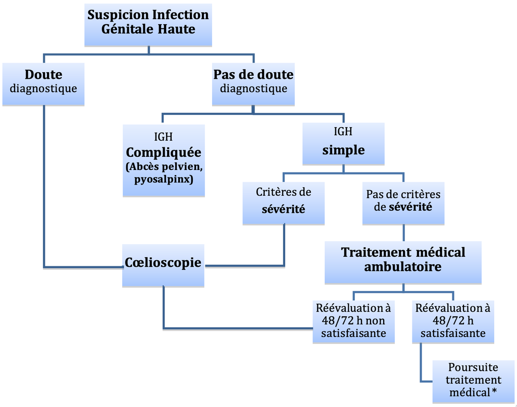

### Conduite à tenir

Adapter le traitement antibiotique dès réception des résultats bactériologiques. Noter que l’association Ofloxacine + Métronidazole n’est efficace que dans 50 % des cas sur le gonocoque. Une injection de Ceftriaxone est donc indispensable en cas de recherche positive pour le gonocoque

### Traitement médical ambulatoire (cf. Tableau 1)

- Antibiothérapie, durée 10 jours (peut être prolongée selon évolution clinique)
  - En première intention
  - Ceftriaxone 1g IM 1 fois, Doxycycline 100 mg x 2 / j per os et Métronidazole 500 mg x 2 / j per os
  - Alternative : Ofloxacine 200 mg x 2 per os + Métronidazole 500 mg x 2 / j per os
- Traitement partenaire(s)
  - Azithromycine(1grmonodose)
- Anti-inflammatoires non stéroïdiens pendant les 5 premiers jours en dehors de contre-indication

### Prise en charge IGH compliquée (cf. tableau 2)

- Hospitalisation
- Chirurgie d’emblée ou traitement médical premier puis cœlioscopie après 36-48 h
- Antibiothérapie parentérale
  - Métronidazole 1,5 g / j + doxycycline 200 mg / j + Ceftriaxone 1 g à 2 g
  - Selon gravité clinique +/- Gentamicine (2 mg/kg dose de charge puis 4,5mg/kg par jour)
  - Relai per os selon amélioration clinique et après 48 h apyrexie
    - En première intention Ofloxacine + Métronidazole (cf. supra)
    - À adapter aux résultats bactériologiques

Durée 14 à 21 jours, selon évolution clinique et biologique (CRP)

### Prise en charge à distance

- Rappel : toutes les patientes sont revues 48 à 72 h après l’instauration du traitement antibiotique ambulatoire par l’interne des urgences pour évaluation de l’efficacité du traitement (clinique, biologique et échographique). Si évolution non satisfaisante, cœlioscopie.
- Toutes les patientes doivent être revues en consultation 3 à 4 semaines après l’épisode infectieux initial par le sénior d’astreinte le jour de la réévaluation ou par le sénior auprès duquel un avis a été sollicité.
- En cas de désir de grossesse après une infection génitale haute compliquée une cœlioscopie de second look doit être proposée 6 à 8 semaines après l’épisode infectieux

### Références

1. Ross J et al. European Guideline for the management of pelvic inflammatory disease. Int J STD AIDS 2007 ; 18 : 662-6.
2. Centers for diseases Control and Prevention. Sexually transmitted diseases treatment guidelines, 2006. MMWR 2006 ; 55(RR-6) : 1-94.
3. Judlin PG et al. Physiopathologie, diagnostic et prise en charge des infections geÃÅnitales hautes. Gynecol Obstet Fertil 2009 ; 37 : 172-182.
4. RPC CnGOF 2018

### Tableau 1

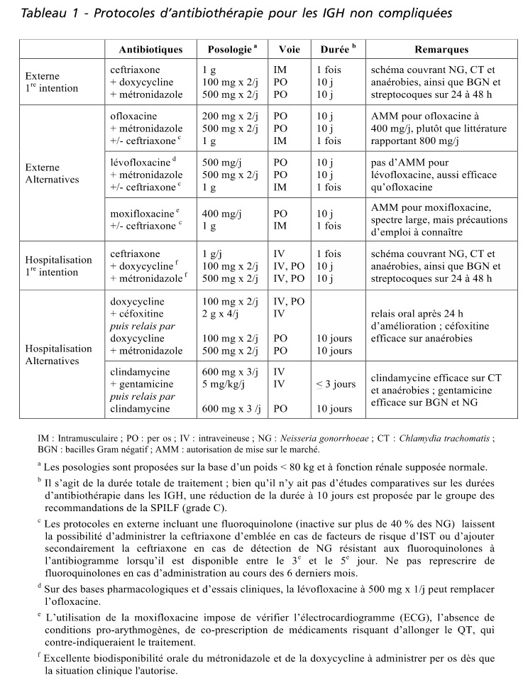

### Tableau 2

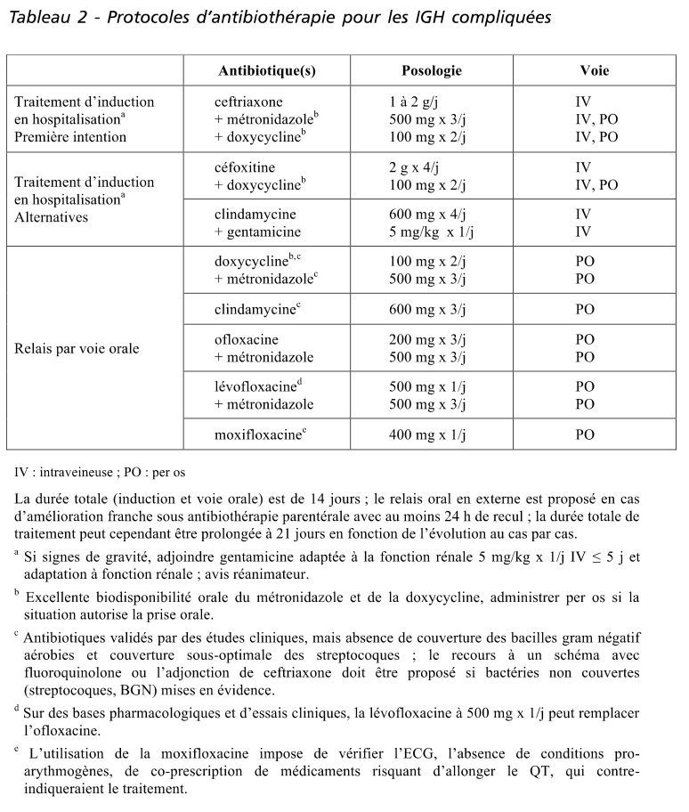

# PROTOCOLE GROSSESSES ARRETEES

[interactive chart not shown]

### Grossesse intra-utérine de vitalité incertaine

#### Situation clinique :

- **Menace de FCS** (+ /- hématome sous-chorial)
- **SG < 20 mm** et/ou embryon < 5 mm sans AC visualisée

#### Attitude thérapeutique :

#### Expectative

- **Contrôle échographique de l’évolutivité à 7/10 jours**
- Anti-D si Rhésus négatif en cas de métrorragies

### FCS en cours

#### Situation clinique :

1. **Hémorragique**
2. **Non hémorragique**

(SG +/- en voie d’expulsion)

#### Attitude thérapeutique :

#### Hospitalisation

1. **Aspiration chirurgicale en urgence**
2. **Expectative :**
   - Antalgiques (AINS,paracétamol)
   - Contrôle échographique de l’expulsion du SG. Si non-expulsion,traitement chirurgical ou médical.

### FCS supposée complète

#### Situation clinique :

- Amendement des douleurs et des saignements, col fermé
- **Vacuité utérine probable** : endomètre échogène, homogène (mesure AP < 15 mm)
1. **Expulsion de produit de conception**
2. **Grossesse de localisation incertaine** : Grossesse intra-utérine préalable non connue, absence de recueil de matériel d’expulsion.

#### Attitude thérapeutique :

#### Expectative

1. **Analyse histologique du produit d’expulsion**
2. **hCG plasmatiques** le jour même et à 48 h (afin de ne pas méconnaître une GEU).

### FCS incomplète (rétention trophoblastique)

#### Situation clinique :

- SG expulsé
- Images intra-utérines hyperéchogènes (mesure AP > 15 mm)
1. **Saignements importants** et/ou douleurs
2. **Amendement** des douleurs expulsives et des saignements, col ouvert.

#### Attitude thérapeutique :

1. **Aspiration chirurgicale**
2. **Expectative :**
- Pas d’hospitalisation
- Réévaluation clinique et échographique à 1 ou 2 semaines et après les règles
- Consignes de consultation en urgence
- Si persistance rétention après contrôles, hystéroscopie opératoire.

### Grossesse arrêtée (FCS retardée)

#### Situation clinique :

- Saignements et/ou douleurs modérées, col fermé
- SG>20mmvide
- **Ou** embryon sans AC > 5 mm
- **Ou** SG hypotonique, hétérogène, non évolutif à une semaine

#### Attitude thérapeutique :

#### Technique de référence : aspiration chirurgicale

- Dans les 48 h (après bilan et consultation ARE)
- Anesthésie locale possible

#### Traitement médical : misoprostol (MisoOne®) à donner aux urgences

- **Critères d’exclusion**
  - Repos (arrêt de travail), information éclairée - Prescription d’antalgiques (AINS, paracétamol)
  - Pas de bilan ni de consultation ARE systématique
- MisoOne® 400μg PO 3 fois par jour 48h
  - Réévaluation à 1 semaine et 1 mois, quelle que soit la mesure AP des images hyperéchogènes intra-utérines.
  - Indications de geste chirurgical : persistance de saignements abondants.

SG : sac gestationnel, mesure AP : mesure antéro-postérieure sur une coupe sagittale

AC : activité cardiaque embryonnaire

a: Consignes de consultation en urgence en cas d’expectative : persistance de saignements abondants (> règles), apparition de douleurs et/ou de fièvre.

b: Critères d’exclusion du traitement médical:LCC > 30 mm et/ou SG > 40 mm de diamètre moyen, domiciliée > 30 minutes de l’hôpital, impossibilité d’être accompagnée quelle que soit l’heure.

c: Informations à donner aux patientes : risques de l’expulsion spontanée (saignements, douleurs expulsives) et d’un geste chirurgical complémentaire (absence d’expulsion complète, fausse couche hémorragique), éventuels effets secondaires digestifs, nécessité d’une surveillance ambulatoire clinique et échographique.

### Références :

1. Royal College of Obstetricians and Gynaecologists. The management of earlypregnancyloss. ROCG guideline n° 25. London : ROCG Press ; 2006.
2. Beucher G et al. Prise en charge des fausses couches spontanées du premier trimestre. GynecolObstetFertil 2009 ; 37 : 257-64.
3. Sotiriadis et al. Expectant, medical or surgical management of first trimestermiscarriage : a meta-analysis. ObstetGynecol 2005. 105 : 1104-13.
4. Recommandation temporaire d’utilisation du misoprostol ANSM février 2018
5. Recommandation perte de grossesse CNGOF 2014

# NUMÉROS UTILES

| PR | Tel |
| --- | --- |
| Accueil urgence | 13592 |
| Interne gyneco chir | 15426 |
| Assistante sociale | 14075/13717 |
| Pyschologue (Mme Antoine) | 13582 |
| Salle Palmer | 13656 |
| Salle Musset | 13664 |
| Cadre hospit (Mme Odic) | 15238 |
| SDN | 13692 |
| Interne obs | 13943/13944 |
| Interne PMA | 15420 |
| Interne DAN | 14514 |
| **Bloc** | **Tel** |
| Régulation journée | 13686 |
| IBODE | 13848 |
| Brancardier | 15118/13949 |
| Interne anesth | 13952/13953 |
| Senior anesth | 13950/13951 |
| Salle 5 | 16687 |
| SSPI | 16694 |
| SSPI Fax | 13912 |
| Accueil UCA | 13028 |
| Bloc Fax | 13689 |
| **Avis spé** | **Tel** |
| Interne Gyneco med | 15501 |
| Interne uro | 15088 |
| Interne dig | 14004 |
| Orthogénie | 13861/13863 |
| Psy | 12938 |
| Institut Curie | 2387 |
| **SAU** | **Tel** |
| Senior SAU | 12721 |
| Interne SAU | 14059 |
| Cadre SAU | 15438 |
| Radio de garde | 15095 |
| TDM SAU | 15314/12467 |
| Manip radio B | 12514/15094 |
| Radio A/Fax | 12469/12475 |
| TDM A | 18978/12285 |
| IRM | 12798 |
| **Labo** | **Tel** |
| Anapath | 11468 |
| EFS/Fax | 12667/12681 |
| Labo de garde | 11613 |
| Bacterio | 13414/18197 |
| Avis infectieux | 14111 |
| Bioch | 11613/11918/18401 |
| Viro | 13330 |
| Hemato | 18439 |
| Pharmacie | 14231 |
| Centre de tri | 13181/11613 |
| Anapath Lyon | 04 78 86 66 78 |
| Anapath Lyon fax | 04 78 86 65 54 |
| Foetopath Necker | 01 44 49 49 82 |
| **DECT Chef** | **Tel** |
| Dr Abo | 13612 |
| Dr Bourret | 15467 |
| Dr Campin | 14287 |
| Dr Chougrani | 13612 |
| Dr Gaudet Chardonnet | 15434 |
| Dr Marcellin | 15495 |
| Dr Marzouk | 15204 |
| Dr Pierre | 15428 |
| Dr Pirot | 15303 |
| **Assisantes médico-administrative** | **Tel** |
| E. Bonmarchand | 13681 |
| J. Comeau | 13661 |
| M-H De Jesus | 13680 |
| G Gouet | 13669 |
| N. Mehidi | 13670 |
| Fax | 13662/13672 |

# CODAGES UTILES

### UH

#### Bloc 1er étage

**834** BLOC CHIR GYNECO / **835** ANESTH. PORT ROYAL

#### UCA

**477** UCA BLOC GYNECO CHIR / **573** UCA ANESTHESIOLOGIE

| Code | Intitulé |
| --- | --- |
| **ASPIRATION** |  |
| JNJD002 | évac. ut. gravide aspi. +/- curetage 1er trim. |
| JNJP001 | évac. ut. gravide moy. médict 1er trim. |
| JNMD001 | révision cav. ut. après avort. |
| **TORSION ANNEXE** |  |
| ZCQC002 | explo. cav. abd. coelio. |
| ZCQA001 | laparo explo |
| JJEC001 | détorsion annexe coelio. |
| JJFC003 | kystectomie ovarienne périt. coelio. |
| JJFC010 | salpingoovariectomie coelio. |
| JJFC008 | ovariectomie unilat. coelio. |
| **GEU** |  |
| JJFC001 | salpingectomie pr G.E.U coelio. |
| JJJC002 | expression tubaire G.E.U coelio. |
| JJLJ001 | inj. intraovulaire pr G.E.U v.basse +guid écho |
| JJJA002 | expression tubaire G.E.U laparo |
| JJFA001 | salpingectomie pr G.E.U laparo |
| JJPA001 | salpingotomie +aspi. G.E.U laparo |
| JJPC001 | salpingotomie +aspi. G.E.U coelio. |
| **PELVI-PERITONITE** |  |
| ZZHJ003 | pct 1org. prof. sur 1cible v. cav. +guid écho |
| JJJC001 | évac. collection annexe/lig. large coelio. |
| ZCJC001 | évac. collection abdo. coelio |
| QZJA011 | évac. collection prof. ab. direct |
| HHFA016 | appendicectomie coelio/laparo +prépa. coelio. |
| **VULVE** |  |
| JMPA001 | incision glde Bartholin |
| JLFA002 | exérèse lés. vag. |
| JLCA008 | suture vag. |
| JLJB001 | évac. collection paroi vag/vulve v.basse/transcut. |
| JMFA001 | exérèse glde Bartholin |
| **SEIN** |  |
| QEJA001 | évac. collection gld mamm. ab. direct |
| QEHB001 | pct lés. gld mamm. transcut. sans guid |
| **COL** |  |
| JKCD001 | suture col ut. |
| **HYSTEROSCOPIE** |  |
| JKNE001 | abrasion muq. ut. hystéroscopie |
| JKQE002 | hystéroscopie |
| JKQE001 | hystéroscopie +curetage cav. ut. |
| JKFE001 | polypectom. ut. hystéroscopie |
| JKFE002 | résec. myome ut. hystéroscopie |
| JKGD002 | curetage cav. ut. thérap. |
| **CONSULTATION** |  |
| JNQM001 | écho non morph. grosS av. 11semaines aménorrhée |
| ZCQM007 | écho pelvis féminin pr surv. ovulation |
| JKLD001 | pose 1DIU |
| JKGD004 | abl. 1DIU v. vag. |
| QZGA002 | abl/changt implant pharmaco sscut |
| QZLA004 | pose implant pharmaco sscut |
| JKFD001 | exérèse lés. péd. ut. accouchée col v. vag. |
| JLHA001 | biopsie vag. |
| JMHA001 | biopsie vulve |

# PLANNING COURS

### PROGRAMME DES COURS AUX INTERNES

Novembre 2020 – Avril 2021

Horaire : 18h00 - Salle de staff, Chefferie de Service, Deuxième étage

Responsable : Dr Bourdon Mathilde

| Dates | Cours | Intervenant. |
| --- | --- | --- |
| 10.11 | Organisation et gestion d’un bloc opératoire | M. Momperousse |
| 17.11 | FCU et Colposcopie : recommandations | F.Pirot |
| 24.11 | Orthogénie | E. Lhomme |
| Lundi 30.11 | Nouvelles thérapeutiques en Onco-Gynécologie | J. Alexandre |
| 08.12 | Ménopause | L.Maitrot Mantelet |
| 15.12 | Bases des traitements en AMP | C.Maignien |
| 05.01 | Hyperstimulation ovarienne | M. Bourdon |
| 12.01 | Prolapsus et incontinence urinaire | A Bourret |
| 19.01 | Bibliographie$ | A Gaudet Chardonnet |
| 26.01 | Pathologie bénigne de la vulve | P. Marzouk |
| Lundi 01.02 | Imagerie de l’endométriose | AE. Millischer |
| 09.02 | Prise en charge des kystes ovariens | A Gaudet Chardonnet |
| 16.02 | Bibliographie$ | C Abo |
| Lundi 01.03 | Infertilité et endométriose | P. Santulli |
| 09.03 | Consultation d’annonce | V. Antoine/ H Salvaneix |
| 16.03 | Endométriose pelvienne profonde | C. Chapron |
| 23.03 | Cancer du Col | B. Borghèse |
| 30.03 | Contraception | G. Plu-Bureau |
| 06.04 | Endométriose et grossesse | L. Marcellin |
| 13.04 | Bibliographie$ | F Kefelian |

$ Séance bibliographique de trois articles présentés par trois internes, encadrées par tous les CCA, assistants et les PH disponibles.

# PLANNING BLOC

| Jour | Date | Salle.1 | Salle.2 | Salle.3 | UCA |
| --- | --- | --- | --- | --- | --- |
| Lundi | 29/03/2021 |  | CC+AGC / CC (AGC) |  | CA |
| Mardi | 30/03/2021 |  | CC+CA / CC (CA) | BB+AGC | LM |
| Mercredi | 31/03/2021 | AB | PM | AGC | PMA |
| Jeudi | 01/04/2021 |  | FD | LM | PM |
| Vendredi | 02/04/2021 |  | BB | BB (CA) / CA | GP |
|  | 03/04/2021 |  |  |  |  |
|  | 04/04/2021 |  |  |  |  |
| Lundi | 05/04/2021 |  |  |  |  |
| Mardi | 06/04/2021 |  | CC+FP / CC (FP) | LM | LC |
| Mercredi | 07/04/2021 | BB | AB | PMA | PM |
| Jeudi | 08/04/2021 |  | PM | LC | FD |
| Vendredi | 09/04/2021 |  | AGC | GP | BB / CA |
|  | 10/04/2021 |  |  |  |  |
|  | 11/04/2021 |  |  |  |  |
| Lundi | 12/04/2021 |  | CC+FP / CC (FP) |  | AGC |
| Mardi | 13/04/2021 |  | CC+FP / CC (FP) | BB+AGC | FP |
| Mercredi | 14/04/2021 | AB | FP |  | PMA |
| Jeudi | 15/04/2021 |  | FD | LC | PM |
| Vendredi | 16/04/2021 |  | BB | BB (FP) / FP | GP |
|  | 17/04/2021 |  |  |  |  |
|  | 18/04/2021 |  |  |  |  |
| Lundi | 19/04/2021 |  | CC+CA / CC (CA) | FP | AB |
| Mardi | 20/04/2021 |  | CC+CA / CC (CA) | LM | LC |
| Mercredi | 21/04/2021 | BB | AB | PMA | PM |
| Jeudi | 22/04/2021 |  | PM | LC | FD |
| Vendredi | 23/04/2021 |  | AGC | GP | CA |

# PLANNING GARDE

| JOURS | DATES | GARDE.1 | GARDE.2 | GARDE.CHEF.1 | GARDE.CHEF.2 | ASTREINTE.GYNECO |
| --- | --- | --- | --- | --- | --- | --- |
| JEUDI | 01/04/2021 | ZAROKIAN | HANMER | ALESSANDRINI | MARCELLIN |  |
| VENDREDI | 02/04/2021 | DE LOGIVIERE | MAHEUT | TSATSARIS | MARZOUK |  |
| SAMEDI | 03/04/2021 | WARTELLE | BAH | BENIN | GAUDET CHARDONNET |  |
| DIMANCHE | 04/04/2021 | DE LOGIVIERE | OUASTI | MELLE | ABO |  |
| LUNDI | 05/04/2021 | WARTELLE | JOBIN | COLLINOT | GAUDET CHARDONNET |  |
| MARDI | 06/04/2021 | NKOBETCHOU | GUIHARD | LE RAY | PIROT |  |
| MERCREDI | 07/04/2021 | DE VRIES | MAHEUT | CHEULOT | KEFELIAN |  |
| JEUDI | 08/04/2021 | WARTELLE | OUASTI | MELLE | GAUDET CHARDONNET |  |
| VENDREDI | 09/04/2021 | GUIHARD | VEYRIE | GRANGE | CAMPIN |  |
| SAMEDI | 10/04/2021 | BENKRITLY | HANMER | GIRAULT | KEFELIAN |  |
| DIMANCHE | 11/04/2021 | ZAROKIAN | JOBIN | COHEN | MARCELLIN |  |
| LUNDI | 12/04/2021 | BRIEUX | HANMER | ANSELEM | GOFFINET |  |
| MARDI | 13/04/2021 | BRIEUX | JOBIN | BENIN | MARCELLIN |  |
| MERCREDI | 14/04/2021 | DE LOGIVIERE | EL HACHEM | TSATSARIS | MAIGNIEN |  |
| JEUDI | 15/04/2021 | GUIHARD | VEYRIE | COHEN | GAUDET CHARDONNET |  |
| VENDREDI | 16/04/2021 | NKOBETCHOU | MAHEUT | LE RAY | MARCELLIN |  |
| SAMEDI | 17/04/2021 | BRIEUX | JOBIN | CHEULOT | PIROT |  |
| DIMANCHE | 18/04/2021 | NKOBETCHOU | MAHEUT | GIRAULT | KEFELIAN |  |
| LUNDI | 19/04/2021 | OLIVO MARIN | OUASTI | COHEN | PIROT |  |
| MARDI | 20/04/2021 | WARTELLE | JOBIN | COLLINOT | ABO |  |
| MERCREDI | 21/04/2021 | DE VRIES | MAHEUT | MELLE | KEFELIAN |  |
| JEUDI | 22/04/2021 | BRIEUX | BAH | TSATSARIS | CAMPIN |  |
| VENDREDI | 23/04/2021 | ZAROKIAN | EL HACHEM | GOFFINET | MAIGNIEN |  |
| SAMEDI | 24/04/2021 | OLIVO MARIN | OUASTI | ALESSANDRINI | ABO |  |
| DIMANCHE | 25/04/2021 | GUIHARD | EL HACHEM | CHEULOT | PIROT |  |
| LUNDI | 26/04/2021 | BENKRITLY | HANMER | GRANGE | GAUDET CHARDONNET |  |
| MARDI | 27/04/2021 | OLIVO MARIN | VEYRIE | GIRAULT | BOURRET |  |
| MERCREDI | 28/04/2021 | BENKRITLY | OUASTI | COLLINOT | PIROT |  |
| JEUDI | 29/04/2021 | ZAROKIAN | JOBIN | ALESSANDRINI | ABO |  |
| VENDREDI | 30/04/2021 | GUIHARD | BAH | ANSELEM | MAIGNIEN |  |

| Promotion | Internes |
| --- | --- |
| Novembre 20 - Mai 21 | . |
|  | Marly BAH |
|  | Sunita HANMER |
|  | Samia OUASTI |
|  | Celia MAHEUT |
|  | Aurore BAUCHET (Medecine générale) |
|  | Tifanny MAZETIER (Medecine générale) |
|  | Flora PETROT (Medecine générale) |
|  | Rami EL HACHEM (PMA) |
|  | Timon JOBIN (PMA) |
|  | Axel VEYRIE (PMA) |
| Mai 20 - Novembre 20 | . |
|  | Laura CARIOT |
|  | Simon CREQUIT |
|  | FLorence LLOUQET |
|  | Guillaume PARPEX |